# MUM 2024-25 Optymalizator

## Sieć neuronowa (NN)

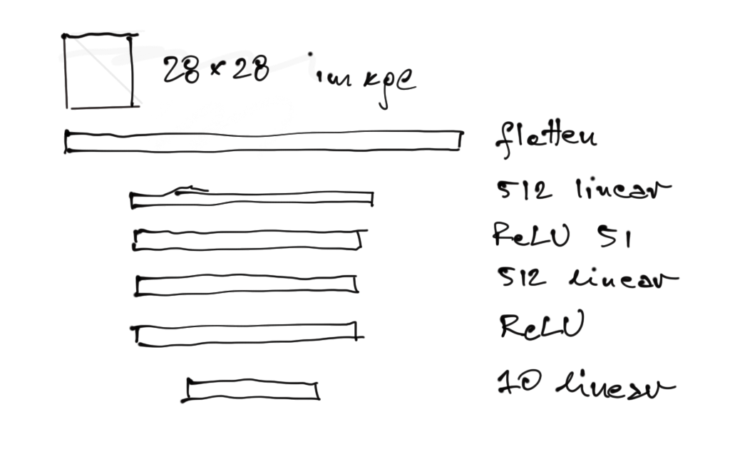

- NN jest wielowymiarową funkcją (zwykle) nieliniową $F:X\longrightarrow Y$
  - dla funkcji zdefiniowana jest różniczkowalna funkcja kosztu $L:Y\times F(X)\longrightarrow \mathbb{R}$
  - uczenie odbywa się w pętli dla optymalizacji parametrów
  - problem MNIST (niespecjalnie dobre rozwiązanie!)
- w Pytorch sieć neuronowa jest zrealizowana jako **graf obliczeniowy**

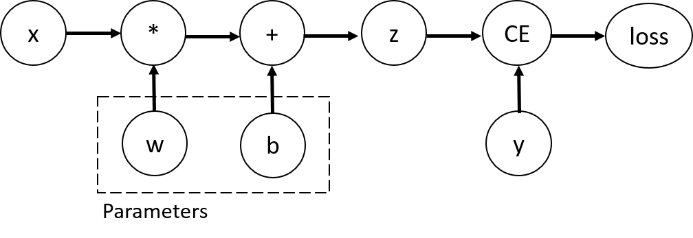

```
class NeuralNetwork(nn.Module):
    # (kod ze tutoriala `Pytorch`)
    def __init__(self):
        super().__init__()
        self.flatten = nn.Flatten()
        self.linear_relu_stack = nn.Sequential(
            nn.Linear(28*28, 512),
            nn.ReLU(),
            nn.Linear(512, 512),
            nn.ReLU(),
            nn.Linear(512, 10),
        )
```

- do tego metoda `forward` obliczająca wartość aktywacji

```
def forward(self, x):
        x = self.flatten(x)
        logits = self.linear_relu_stack(x)
        return logits
```

- `model = NeuralNetwork()` utworzy obiekt tej sieci
- pętla ucząca

```
def train_loop(dataloader, model, loss_fn, optimizer):
  size = len(dataloader.dataset)
  # Set the model to training mode - important for batch normalization and dropout layers
  # Unnecessary in this situation but added for best practices
  model.train()
  for batch, (X, y) in enumerate(dataloader):
      # Compute prediction and loss
      pred = model(X)
      loss = loss_fn(pred, y)

      # Backpropagation
      loss.backward()
      optimizer.step()
      optimizer.zero_grad()
```

- i wykonanie

```
loss_fn = nn.CrossEntropyLoss()
optimizer = torch.optim.SGD(model.parameters(), lr=learning_rate)

epochs = 10
for t in range(epochs):
  print(f"Epoch {t+1}\n-------------------------------")
  train_loop(train_dataloader, model, loss_fn, optimizer)
  test_loop(test_dataloader, model, loss_fn)
```

- funkcja kosztu `loss_fn` musi brać pod uwagę, jakie wartości zwracane są przez model
  - tutaj model zwraca `logits` z przedziału $[-\infty, +\infty]$, stąd `CrossEntropyLoss(x, y)` $$L(x, y) = -\sum_k\log\frac{\exp x_k}{\sum_i\exp x_i}y_k$$
- predykcja modelu

  ```
  logits = model(X)
  pred_proba = nn.Softmax(dim=1)(logits)
  y_pred = pred_proba.argmax(1)
  ```

# **Gradientowa** i **iteracyjna** minimalizacja $L$

- $w$ - wektor wszystkich parametrów modelu rozpoczynając od $w_0$
- $w_t$ - wartość parametrów po $t$ krokach (po czasie $t$)
- krok w czasie $t$ $\Delta _t := w_t-w_{t-1}$
- $L$ - *różniczkowalna* funkcja kosztu
- $\gamma$ - **learning rate**
  - kontroluje szybkość uczenia
    - możliwa jest zmiana w czasie hiperparametru $\gamma_t$
- Wartość $L$ zależy od:
  - danych treningowych i wektora $\theta$
  - architektury modelu
  - być może jeszcze innych stałych
- Optymalizujemy tylko $w$, będziemy pisać w skrócie $L(w_t)$.
- $L$ zwraca wartość: zakładamy, że umiemy policzyć gradient $\nabla L(w)$.

## 😏 Gradient Descent

### Update

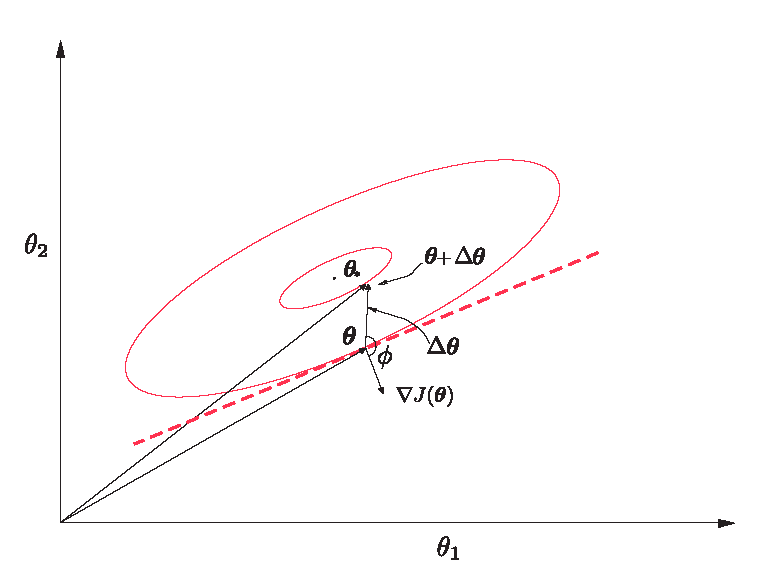

$$w_{t+1}=\theta_{t} - \gamma\nabla L(w_{t})$$

1. $-\nabla L(w_t)$ to kierunek najszybszego spadku $L$
- jednak $-\nabla L(w_t)$ **nie wskazuje** optymalnego kierunku $w$
2. wektor gradientu $\nabla L(w_t)$ jest prostopadły do hiperpłaszczyzny stycznej do powierzchni o równych wartościach funkcji kosztu (*isosurface*) w miejscu $w_t$
3. zmniejszenie $L$ odpowiada **co najmniej** rozwartemu kątowi między $\nabla\theta^{(t)}$ a $\Delta\theta^{(t)}$
4. learning rate $\gamma$
   - mała wartość — spowalnia uczenie
   - duża wartość — powoduje **oscylacje**, problem ze zbieżnością
5. dlaczego nie normalizujemy $\nabla L(w_t)$?
   - duża wartość gradientu to **duża lokalna zmienność $L$** - powinniśmy robić **mniejsze kroki** (precyzyjniej)
   - mała wartość gradientu to **mała lokalna zmienność $L$** - powinniśmy robić **większe kroki** (aby szybciej opuścić **plateau**)
6. wariant GD ze zmiennym w czasie $\gamma$
- malejący w stosunku odwrotnym do kroku uczenia $t$
  - warunki konieczne osiągnięcia optymalnego $\gamma$ $$\begin{align}\sum_t\gamma_t^2\lt\infty\\\sum_t\gamma_t=\infty\end{align}$$
7. niech $\gamma_{opt}$ będzie *optymalna*
- $\gamma<\gamma_{opt}$: uczenie będzie postępować zbyt małymi krokami
- $\gamma=\gamma_{opt}$: uczenie powinno być jednokrokowe (funkcja $L$ wypukła)
- $\gamma>\gamma_{opt}$: duże oscylacje uczenia jednak zbieżne do minimum
- $\gamma\geq2\gamma_{opt}$: niebezpieczeństwo wyskoczenia i rozbieżności w uczeniu
8. zwykle jednak w praktyce najszybsza zbieżność jest osiągana przy $\gamma$ bliskim tej dla rozbieżności
- należy używać jak największej $\gamma$ ale nie większej ;-)

**GD jest najgorszą możliwą metodą optymalizacji** 😏 😒 😩 😒 😞

## Stochastic gradient descent SGD

$$w_{t+1}=w_t-\gamma_t\nabla{}L_i(w_t)$$ gdzie indeks $i$ wskazuje na wybrany losowo przykład (z rozkładu równomiernego)

- to **najlepsza metoda optymalizacji** dlaczego?!?!
- można spojrzeć na SGD jako GD z szumem
  - przy uczeniu wielu przykładów jest duży stopień *redundancji* przykładów, chociażby wiele tych samych cyfr w MNIST
  - w początkowych krokach szum jest niewielki w porównaniu do informacji w gradiencie
    - krok SGD jest równie dobry jak krok GD
  - szum może zabezpieczyć przed wpadnięciem do lokalnego (niepoprawnego) minimum
    - to przypomina *annealing* - uczenie z *explicite* dodanym stochastycznym szumem malejącym wraz z postępem uczenia
  - SGD jest drastycznie szybsze od GD i można wykonać tym samym kosztem tysiące kroków zamiast jednego kroku GD

### Hiperparametr stałej uczenia

- optymalna wartość stałej uczenia zależy od wielkości zbioru uczącego,
- a także od od wielkości batchu

[wizualizacja [deeplearning.ai]](https://www.deeplearning.ai/ai-notes/optimization/index.html)

## Mini batches

$$w_{t+1}=w_t-\gamma_t\frac{1}{|B_i|}\sum_{i\in{}B_i}\nabla{}L_i(w_t)$$

- istotny jest element $1/|B_i|$
- w oczywisty sposób można lepiej wykorzystać sprzęt, w szczególności GPU
- bardzo przydatne dla urównoleglenia uczenia

## Momentum

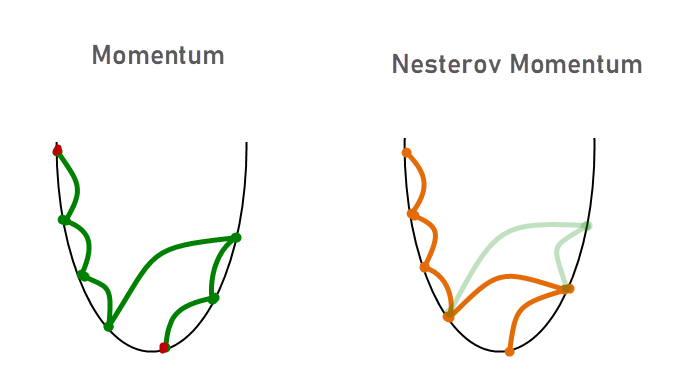

- SGD z momentum to SGD z dodanym efektem ciężkiej kuli podążającej dotychczasowym kierunkiem $$\begin{align*} p_{t+1} &= \nabla L_i(w_t) + \beta p_t\\ w_{t+1}&=w_t - \gamma{}p_{t+1}=w_t - \gamma{}\nabla L_i(w_t) - \gamma\beta{}p_t\\ &\textrm{ponieważ}\\ p_t&=\nabla L_i(w_{t-1}) + \beta p_{t-1}\\ w_t&=w_{t-1} - \gamma{}p_t\\ -\gamma{}p_t&=w_t-w_{t-1}\\ &\textrm{stąd}\\ w_{t+1}&=w_t - \gamma_t\nabla L_i(w_t) + \beta(w_t-w_{t-1}) \end{align*}$$ gdzie ostatni składnik jest dodatkowy względem SGD

0. Krok staje się kombinacją poprzedniego kierunku i negatywnego gradientu
1. Analogia do kulki toczącej się ze wzgórza, $\beta$ to tarcie lub opór powietrza
2. **Pamięć**
   - wzajemnie wzmacniają się kroki w **istotnym kierunku** i kierunek nie jest zmieniany natychmiast
   - **oscylacje** są tłumione i uśredniają się do małej wartości
   - mniejsze spowolnienie na **plateau**, jeśli "kulka" była rozpędzona
3. wartości hiperparametru $\beta=0.9$ lub $\beta=0.99$ sprawdzają się prawie zawsze
   - zwykle zwiększenie $\beta$ powinno skutkować *zmniejszeniem* $\gamma$ dla utrzymania zbieżności

To jest ten *free lunch*, którego podobno niema 😏

## Nesterov accelerated gradient NAG

- NAG jest wyjściem o jeden krok do przodu i wzięciem wartości w miejscu, gdzie optymalizator dopiero się znajdzie $$\begin{align} p_{t+1} &= \nabla L_i(w_t) + \beta{}p_t\\ w_{t+1}&=w_t - \gamma_t(\nabla L_i(w_t)+\beta{}p_{t+1})\\ &=w_t - \gamma_t(1+\beta)\nabla L_i(w_t) - \gamma_t\beta^2p_t \end{align}$$
  - zgrubne oszacowanie *prawdopodobnego* nowego $w_{t+1}=w_t-\gamma_t p_{t+1}$
  - gradient liczony w nowym miejscu — rozszerzenie momentum z *ekstrapolacją*
- większe $\beta$ powoduje wolniejszą reakcję na zmianę powierzchni błędu
- można pokazać, że NAG przyspiesza uczenie dla wypukłych funkcji i (bardzo) dobrze dobranych parametrów
- momentum też przyspiesza, ale jedynie na kwadratowych powierzchniach funkcji błędu
- nie ma teoretycznych wyników pokazujących przyspieszenie NAG dla sieci neuronowych, chociaż często takie obserwujemy
  - dla sieci neuronowych zwykle NAG zachowuje się równie dobrze jak momentum
- przyspieszenie oraz wygładzanie szumu wpływa na lepsze zachowanie algorytmów momentum i NAG

## SGD a Momentum a NAG

$$ \begin{alignat}{5} w_{t+1}&=w_t-\gamma_t\nabla{}L_i(w_t)\\ w_{t+1}&=w_t - \gamma_t{}\nabla L_i(w_t) + \beta(w_t-w_{t-1})\\ w_{t+1}&=w_t - \gamma_t(1+\beta)\nabla L_i(w_t) - \gamma\beta^2p_t \end{alignat} $$

[wizualizacje algorytmów [deeplearning.ai]](https://www.deeplearning.ai/ai-notes/optimization/index.html)